# Task 3 : Visualization using Histogram

- Create a histogram or bar chart to visualize the distribution of data in a dataset

In this task i simply plot the

1. Histograms
2. barplot
3. distplot
4. facetgrid bar

# Step 1 Import library

```python
# import Libraries
import pandas as pd
import numpy as np
import matplotlib.pyplot as plt
import seaborn as sns
%matplotlib inline
```

# Step 2 Read Csv files

```python
df = pd.read_csv('iris.csv')
```

# Step 3 Getting information about the Dataset

```python
df.info()
```

```
<class 'pandas.core.frame.DataFrame'>
RangeIndex: 150 entries, 0 to 149
Data columns (total 5 columns):
 #   Column        Non-Null Count  Dtype
---  ------        --------------  -----
 0   sepal_length  150 non-null    float64
 1   sepal_width   150 non-null    float64
 2   petal_length  150 non-null    float64
 3   petal_width   150 non-null    float64
 4   species       150 non-null    object
dtypes: float64(4), object(1)
memory usage: 6.0+ KB
```

```python
df
```

|  | sepal_length | sepal_width | petal_length | petal_width | species |
| --- | --- | --- | --- | --- | --- |
| 0 | 5.1 | 3.5 | 1.4 | 0.2 | setosa |
| 1 | 4.9 | 3.0 | 1.4 | 0.2 | setosa |
| 2 | 4.7 | 3.2 | 1.3 | 0.2 | setosa |
| 3 | 4.6 | 3.1 | 1.5 | 0.2 | setosa |
| 4 | 5.0 | 3.6 | 1.4 | 0.2 | setosa |
| ... | ... | ... | ... | ... | ... |
| 145 | 6.7 | 3.0 | 5.2 | 2.3 | virginica |
| 146 | 6.3 | 2.5 | 5.0 | 1.9 | virginica |
| 147 | 6.5 | 3.0 | 5.2 | 2.0 | virginica |
| 148 | 6.2 | 3.4 | 5.4 | 2.3 | virginica |
| 149 | 5.9 | 3.0 | 5.1 | 1.8 | virginica |

150 rows × 5 columns

```python
df['species'].unique()
```

```
array(['setosa', 'versicolor', 'virginica'], dtype=object)
```

```python
df.groupby('species').count()
```

| species | sepal_length | sepal_width | petal_length | petal_width |
| --- | --- | --- | --- | --- |
| setosa | 50 | 50 | 50 | 50 |
| versicolor | 50 | 50 | 50 | 50 |
| virginica | 50 | 50 | 50 | 50 |

# Histograms

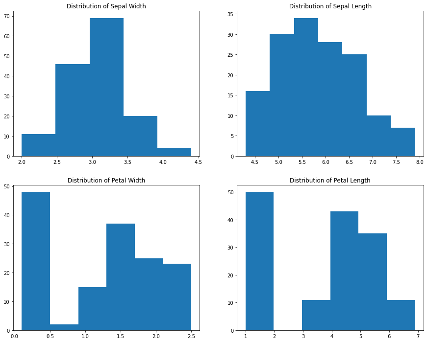

```python
 fig, axes = plt.subplots(2, 2, figsize=(15,12))
axes[0,0].set_title("Distribution of Sepal Width")
axes[0,0].hist(df['sepal_width'], bins=5);
axes[0,1].set_title("Distribution of Sepal Length")
axes[0,1].hist(df['sepal_length'], bins=7);
axes[1,0].set_title("Distribution of Petal Width")
axes[1,0].hist(df['petal_width'], bins=6);
axes[1,1].set_title("Distribution of Petal Length")
axes[1,1].hist(df['petal_length'], bins=6);
```

observation

1 . higest frequency of sepal width is between 3.0 to 3.5 and lower frequency is between 4.0 to 4.4

2 . higest frequency of sepal length is between 5.5 to 6.0 and lower frequency between 7.5 to 7.4

# barplot

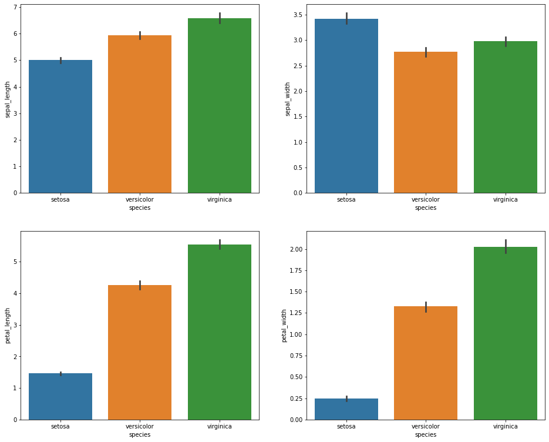

```python
fig, axes = plt.subplots(2, 2, figsize=(16,13))
sns.barplot(y='sepal_length',x='species',data=df,ax=axes[0,0])
sns.barplot(y='sepal_width',x='species',data=df,ax=axes[0,1])
sns.barplot(y='petal_length',x='species',data=df,ax=axes[1,0])
sns.barplot(y='petal_width',x='species',data=df,ax=axes[1,1])
```

observation

setosa length is always smaller size species in all the comparision expect in sepal width it have largest sepal weidth among all species

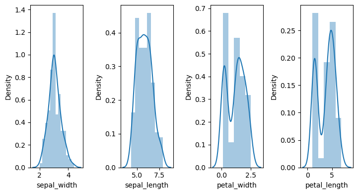

```python
cols = ['sepal_width', 'sepal_length', 'petal_width', 'petal_length']
plt.figure(figsize=(20,4), dpi=100)
i = 1
for col in cols:
    plt.subplot(1,11,i)
    sns.distplot(df[col])
    i = i+1
plt.tight_layout()
plt.show()
```

observation

show the average distribution with respect to density in each columns

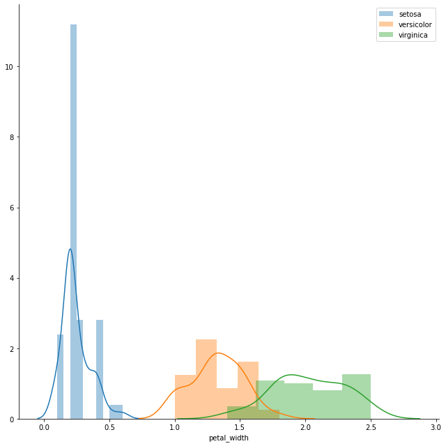

```python
sns.FacetGrid(data=df,hue="species",height=9).map(sns.distplot,"petal_width")
plt.legend(bbox_to_anchor=(1,1))
```

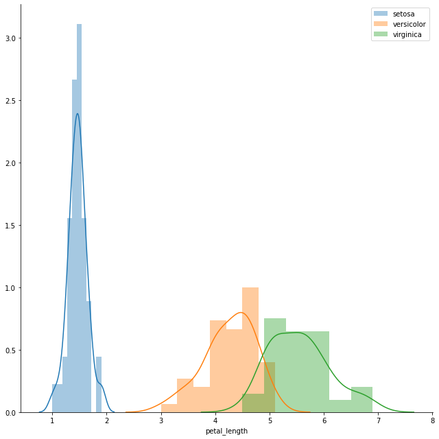

```python
sns.FacetGrid(data=df,hue="species",height=9).map(sns.distplot,"petal_length")
plt.legend(bbox_to_anchor=(1,1))
```

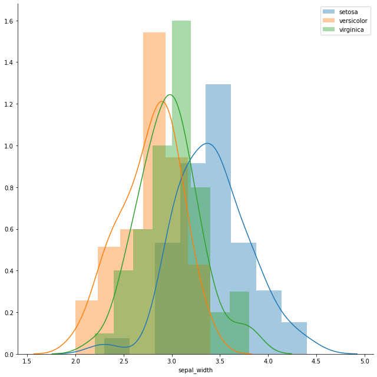

```python
sns.FacetGrid(data=df,hue="species",height=9).map(sns.distplot,"sepal_width")
plt.legend(bbox_to_anchor=(1,1))
```

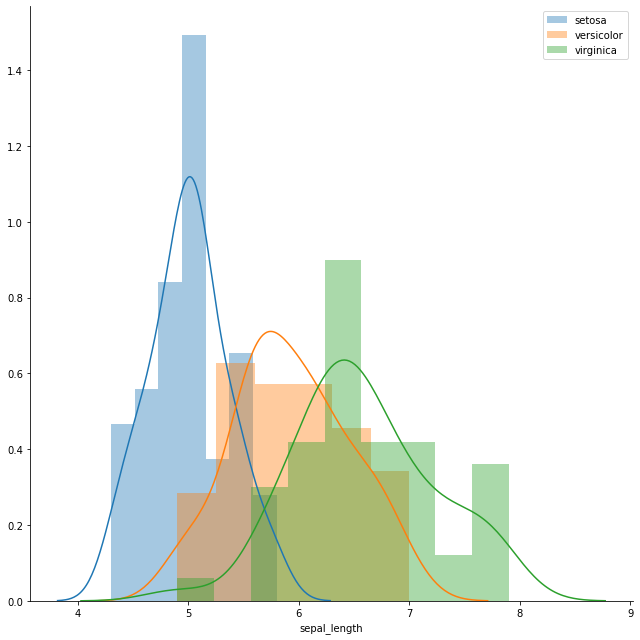

```python
sns.FacetGrid(data=df,hue="species",height=9).map(sns.distplot,"sepal_length")
plt.legend(bbox_to_anchor=(1,1))
```

observation in above 4 graphs

petal length and petal width setosaa is get seprated clearly